# Text Prediction App - Milestone Report

DMK

8/24/2020

### Summary

This final project (Capstone) for Data Science Specialization requires developing a text prediction Shiny App. The app is “taught” to predict next word in a sentence by training it using three files provided via Coursera / Swiftkey. For the purpose of this submission, English language files are utilized.

### Steps

#### Setup

- Load required packages

### Explore Files

- Gather information on total lines & average word count per line in datasets

```r
Twitter <- file("./final/en_US/en_US.twitter.txt")
Blogs <- file("./final/en_US/en_US.blogs.txt")
News <- file("./final/en_US/en_US.news.txt")

length(readLines(Twitter, skipNul = TRUE))
```

```
## [1] 2360148
```

```r
wordcount(readLines(Twitter, skipNul = TRUE), count.function = mean)
```

```
## [1] 12.86936
```

```r
length(readLines(Blogs, skipNul = TRUE))
```

```
## [1] 899288
```

```r
wordcount(readLines(Blogs, skipNul = TRUE), count.function = mean)
```

```
## [1] 41.51521
```

```r
length(readLines(News, skipNul = TRUE))
```

```
## [1] 1010242
```

```r
wordcount(readLines(News, skipNul = TRUE), count.function = mean)
```

```
## [1] 34.02406
```

### Collect Sample Corpus

Approx. 2% of data is used in training set

```r
set.seed(5432)
TwitSample <- sample(readLines(Twitter, skipNul = TRUE), size = 50000, replace = TRUE)
BlogSample <- sample(readLines(Blogs, skipNul = TRUE), size = 21500, replace = TRUE)
NewsSample <- sample(readLines(News, skipNul = TRUE), size = 19000, replace = TRUE)
TrainSet <- c(TwitSample, BlogSample, NewsSample)
rm(TwitSample, BlogSample, NewsSample)
# TrainSet <- Corpus(VectorSource(Train))
```

### Cleanse Data

- Data is cleansed by removing punctuations, white spaces, numbers, etc.

```r
TrainSet <- removeWords(TrainSet, Profanities)
TrainSet <- tolower(TrainSet)
TrainSet <- removePunctuation(TrainSet)
TrainSet <- removeNumbers(TrainSet)
TrainSet <- str_squish(TrainSet)
TrainSet <- str_trim(TrainSet)
```

- After cleansing data, 1-, 2-, & 3-grams are created and saved as dataframes

```r
#UniGram
TrainSet <- TrainSet[str_count(TrainSet, "\\s+")>1]
Gram1 <- ngram(TrainSet, n=1)
UniGram <- get.phrasetable(Gram1)

#BiGram
TrainSet <- TrainSet[str_count(TrainSet, "\\s+")>2]
Gram2 <- ngram(TrainSet, n=2)
BiGram <- get.phrasetable(Gram2)

#TriGram
TrainSet <- TrainSet[str_count(TrainSet, "\\s+")>3]
Gram3 <- ngram(TrainSet, n=3)
TriGram <- get.phrasetable(Gram3)
```

### Words / phrases appearing most frequently in each n-gram are:

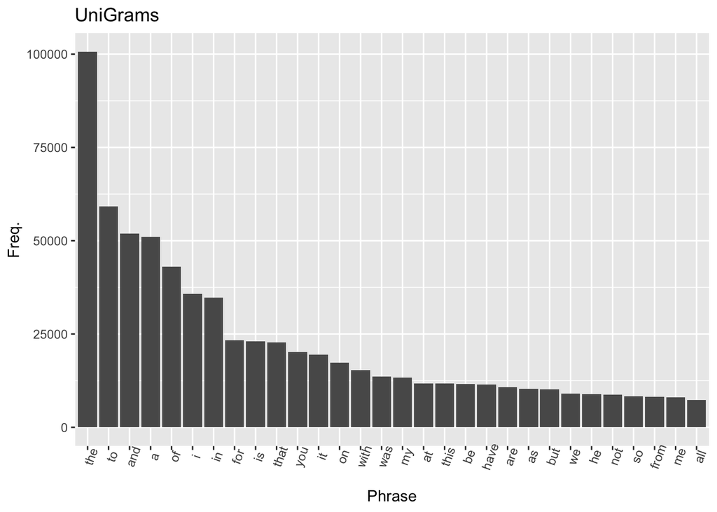

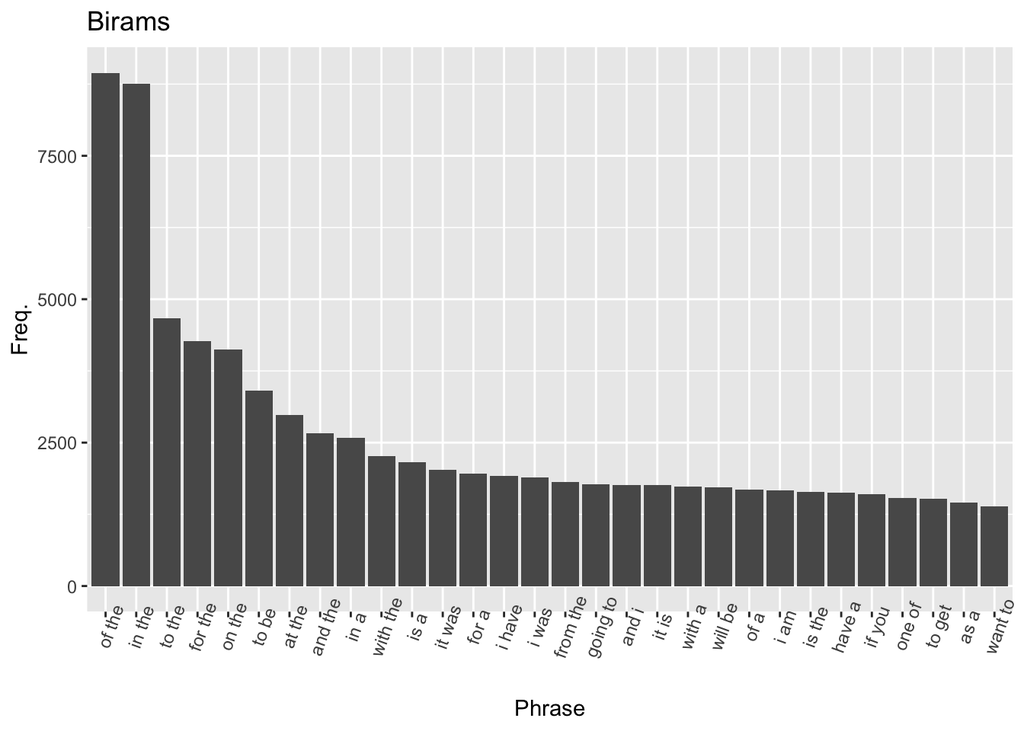

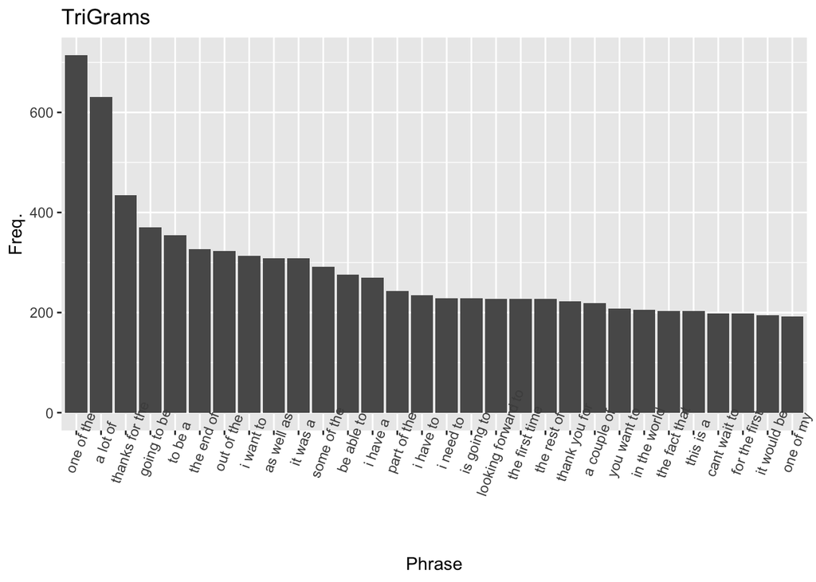

### Next Steps

- Utilize exported Uni-, Bi-, and Tri-grams to build a Shiny App that predicts / proposes next word based on text entered.